# Objektorientierung Teil 2

Informatik II für Geodäsie (522.408, 522.409)  
Informatik 2 (GST.412UF, GST.413UF)

**Sebastian Strasser**

Institut für Geodäsie

28. März 2019

## Ziele

Ziel dieser Einheit ist es

- den Unterschied zwischen Instanz- und Klassenattributen zu verstehen.
- zu wissen, wie sich Methoden, statische Methoden, und Klassenmethoden unterscheiden.
- Properties implementieren zu können und deren Nutzen zu verstehen.
- Vererbung zum Strukturieren von Daten und Funktionalität anwenden zu können.
- zu verstehen, wie Operatoren für Klassen implementiert werden.

## Klassenattribute und -methoden

Bisher wurden nur Attribute und Methoden behandelt, die für eine Instanz einer Klasse definiert sind.

```python
class Robot:
    def __init__(self, name):  # instance method
        self.name = name       # instance attribute

    def sayHello(self):        # instance method
        print("Hallo, ich bin " + self.name)

robot = Robot("Bender")
robot.sayHello()
```

```
Hallo, ich bin Bender
```

### Klassenattribute

- Attribute sind auch für Klassen (nicht nur Instanzen) definierbar
- Klassenattribute sind für alle Instanzen gleich
- Werden auch als **statische** Attribute bezeichnet
- Zugriff über Klasse oder Instanz möglich

```python
class Robot:
    count = 0   # class/static attribute

    def __init__(self):
        Robot.count += 1

robot1 = Robot()
robot2 = Robot()
Robot()
print(Robot.count)  # access via class
print(robot1.count) # access via object
```

```
3
3
```

Die Python-Funktion `type` liefert die Klasse eines Objekts.

- Klassenname muss nicht fest programmiert werden
- Relevant bei Vererbung

```python
class Robot:
    count = 0

    def __init__(self):
        type(self).count += 1  # type(self) = Robot

robot1 = Robot()
robot2 = Robot()
print(Robot.count)
```

```
2
```

### Statische Methoden

Statische Methoden ermöglichen z.B. den Zugriff auf private statische Attribute.

```python
class Robot:
    __count = 0   # private class/static attribute

    def __init__(self):
        type(self).__count += 1

    def robotCount():
        return Robot.__count  # class name has to be hard-coded in this case

robot1 = Robot()
robot2 = Robot()
print(Robot.robotCount())  # access via class
print(robot1.robotCount()) # access via object (will not work)
```

```
2
```

```
---------------------------------------------------------------------------
TypeError                                 Traceback (most recent call last)
<ipython-input-7-f2f27b06eaa3> in <module>
     11 robot2 = Robot()
     12 print(Robot.robotCount())  # access via class
---> 13 print(robot1.robotCount()) # access via object (will not work)

TypeError: robotCount() takes 0 positional arguments but 1 was given
```

Dekorator `@staticmethod` legt Methode als statisch fest, wodurch auch Zugriff über eine Instanz ohne Parameter `self` möglich wird.

```python
class Robot:
    __count = 0   # private class/static attribute

    def __init__(self):
        type(self).__count += 1

    @staticmethod
    def robotCount():
        return Robot.__count # class name has to be hard-coded in this case
robot1 = Robot()
robot2 = Robot()
print(Robot.robotCount())  # access via class
print(robot1.robotCount()) # access via object (now works)
```

```
2
2
```

Statische Methoden sind weder an eine Klasse noch Instanz gebunden! Können z.B. zur logischen Gliederung von Code verwendet werden.

### Klassenmethoden

- Nicht zu verwechseln mit statischen Methoden
- Nicht an Instanz, aber **an Klasse gebunden**
- Erster Parameter (Konvention: `cls`) ist eine Referenz auf die Klasse
- Aufruf über Klasse oder Instanz möglich

```python
class Robot:
    __count = 0   # private class/static attribute

    def __init__(self):
        type(self).__count += 1

    @classmethod
    def robotCount(cls):
        return cls.__count

robot1 = Robot()
robot2 = Robot()
print(Robot.robotCount())  # access via class
print(robot1.robotCount()) # access via object
```

```
2
2
```

Beispiel für Problem von statischen Methoden bei Vererbung

```python
class Pet:
    name = "pet animals"

    @staticmethod
    def about():
        print("This class is about {}.".format(Pet.name))

class Dog(Pet):  # Dog inherits from Pet
    name = "dogs"

class Cat(Pet):  # Cat inherits from Pet
    name = "cats"

pet = Pet()
pet.about()
dog = Dog()
dog.about()
cat = Cat()
cat.about()
```

```
This class is about pet animals.
This class is about pet animals.
This class is about pet animals.
```

Beispiel für Nutzen von Klassenmethoden bei Vererbung

```python
class Pet:
    name = "pet animals"

    @classmethod
    def about(cls):
        print("This class is about {}.".format(cls.name))

class Dog(Pet):
    name = "dogs"

class Cat(Pet):
    name = "cats"

pet = Pet()
pet.about()
dog = Dog()
dog.about()
cat = Cat()
cat.about()
```

```
This class is about pet animals.
This class is about dogs.
This class is about cats.
```

## Properties

Python-Sprachkonstrukt für einen einfachen, gekapselten Zugriff auf Attribute

- Anlegen via Python-Funktion `property` mit zwei Parametern
  - `get`-Methode für Lesezugriff
  - `set`-Methode für Schreibzugriff (optional)
- Ermöglicht Zugriff auf `private` Attribute so als wären sie `public`
- Zugriff erfolgt jedoch gekapselt über `get`- und `set`-Methoden

Properties sollten mit **privaten** `get`- und `set`-Methoden kombiniert werden, damit nicht zwei Wege existieren, um auf Attribute zuzugreifen.

```python
class PropertyTest:
    def __init__(self, x):
        self.__x = x      # private attribute x

    def __getX(self):     # private get method
        return self.__x

    def __setX(self, x):  # private set method
        self.__x = x

    x = property(__getX, __setX)  # get and set methods are passed as parameters to property

test = PropertyTest(1)
test.x = 5              # access attribute x as if it was public
print(test.x * 4)
```

```
20
```

Beispiel: Roboter-Klasse mit Attribut `name`

```python
class Robot:
    def __init__(self, name):
        self.setName(name)    # access via set method

    def sayHello(self):
        print("Hallo, ich bin " + self.getName())  # access via get method

    def setName(self, name):  # set method for name
        if isinstance(name, str): # check if name is a string
            self.__name = name
        else:
            raise TypeError("name must be a string")

    def getName(self):        # get method for name
        return self.__name

robot = Robot("Marvin")
print(robot.getName())                           # access via get method
robot.setName("Marvin, der paranoide Androide")  # access via set method
robot.sayHello()
```

```
Marvin
Hallo, ich bin Marvin, der paranoide Androide
```

Beispiel: Roboter-Klasse mit Attribut `name` als Property

```python
class Robot:
    def __init__(self, name):
        self.name = name  # access via property

    def sayHello(self):
        print("Hallo, ich bin " + self.name)  # access via property

    def __setName(self, name):  # set method is private
        if isinstance(name, str):
            self.__name = name
        else:
            raise TypeError("name must be a string")

    def __getName(self):        # get method is private
        return self.__name

    name = property(__getName, __setName)  # property uses get and set method

robot = Robot("Marvin")
print(robot.name)                              # access via property
robot.name = "Marvin, der paranoide Androide"  # access via property
robot.sayHello()
```

```
Marvin
Hallo, ich bin Marvin, der paranoide Androide
```

### Attribute: `public` vs. `private` mit Kapselung

Allgemeines Mantra in den meisten objektorientierten Sprachen

- Möglichst alle Attribute sollten `private` sein
- Zugriff gekapselt über `get`- und `set`-Methoden

Möglichkeiten durch Properties in Python

- Attribute können vorerst als `public` implementiert werden
- Sollten Zugriffskontrollen notwendig werden, können die Attribute `private` gesetzt und via `get`- und `set`-Methoden gekapselt werden
- **Die Benutzerschnittstelle ändert sich dabei nicht!**

## Vererbung

Definiert die Beziehung zwischen einer allgemeinen Klasse und einer spezialisierten Klasse

- Klassen können auf anderen Klassen aufbauen
- Attribute und Methoden der Basisklasse(n) werden geerbt

Beispiele aus der natürlichen Sprache:

- Fahrzeug: Auto, Lastwagen, Motorrad, Bus, Zug, Schiff, Flugzeug, ...
- Flugzeug: Passagierflugzeug, Frachtflugzeug, Kampfflugzeug, ...

Fahrzeug ist die **Basis-/Oberklasse**, Flugzeug eine **Sub-/Unterklasse**. Flugzeug kann selbst ebenfalls eine Basisklasse für weitere Subklassen sein.

Beispiel: Basisklasse Konto mit Subklassen Sparkonto und Girokonto

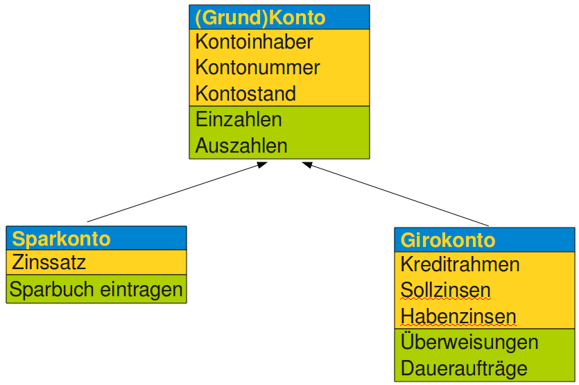

Subklassen erben (übernehmen) Attribute und Methoden der Basisklassen

```python
class Person:  # base class
    def __init__(self, firstName, lastName):
        print("__init__ von Person wurde aufgerufen")
        self.firstName = firstName
        self.lastName = lastName

    def fullName(self):
        print("fullName von Person wurde aufgerufen")
        return self.firstName + " " + self.lastName

class Student(Person):  # sub class that inherits from base class Person
    pass

person  = Person("Carl", "Sagan")
print("Name:", person.fullName())
student = Student("Stephen", "Hawking")
print("Name:", student.fullName())
```

```
__init__ von Person wurde aufgerufen
fullName von Person wurde aufgerufen
Name: Carl Sagan
__init__ von Person wurde aufgerufen
fullName von Person wurde aufgerufen
Name: Stephen Hawking
```

Geerbte Attribute und Methoden können **überschrieben** werden

```python
class Person:  # base class
    def __init__(self, firstName, lastName):
        print("__init__ von Person wurde aufgerufen")
        self.firstName = firstName
        self.lastName = lastName

    def fullName(self):
        print("fullName von Person wurde aufgerufen")
        return self.firstName + " " + self.lastName

class Student(Person):  # sub class that inherits from base class Person
    def fullName(self):
        print("fullName von Student wurde aufgerufen")
        return self.lastName + ", " + self.firstName

person  = Person("Carl", "Sagan")
print("Name:", person.fullName())
student = Student("Stephen", "Hawking")
print("Name:", student.fullName())
```

```
__init__ von Person wurde aufgerufen
fullName von Person wurde aufgerufen
Name: Carl Sagan
__init__ von Person wurde aufgerufen
fullName von Student wurde aufgerufen
Name: Hawking, Stephen
```

Überschriebene Methoden der Basisklasse werden nicht aufgerufen

```python
class Person:  # base class
    def __init__(self, firstName, lastName):
        print("__init__ von Person wurde aufgerufen")
        self.firstName = firstName
        self.lastName = lastName

class Student(Person):  # sub class that inherits from base class Person
    def __init__(self, firstName, lastName):
        print("__init__ von Student wurde aufgerufen")
        self.registrationNumber = None

student = Student("Stephen", "Hawking")
print("Matrikelnummer:", student.registrationNumber)
print("Name:", student.firstName, student.lastName)
```

```
__init__ von Student wurde aufgerufen
Matrikelnummer: None
```

```
---------------------------------------------------------------------------
AttributeError                            Traceback (most recent call last)
<ipython-input-36-09f112a0d407> in <module>
     12 student = Student("Stephen", "Hawking")
     13 print("Matrikelnummer:", student.registrationNumber)
---> 14 print("Name:", student.firstName, student.lastName)

AttributeError: 'Student' object has no attribute 'firstName'
```

### Überschreiben und Überladen

Überschreiben (*overwrite*)

- Erlaubt abgeleiteten Klassen, eine eigene Implementierung einer geerbten Methode zu definieren
- Überschreibende Methode **ersetzt** dabei die geerbte Methode
- Geerbte Methode kann in der überschreibenden Methode via `super()` aufgerufen werden (`super()` liefert Objekt der Basisklasse)

```python
class Person:
    def __init__(self, firstName, lastName):
        pass  # do something

class Student(Person):
    def __init__(self, firstName, lastName):  # override init method
        super().__init__(firstName, lastName)  # call init method of base class
        pass  # do something more
```

Beispiel für Überschreiben einer Methode

```python
class Person:  # base class
    def __init__(self, firstName, lastName):
        print("__init__ von Person wurde aufgerufen")
        self.firstName = firstName
        self.lastName = lastName

class Student(Person):  # sub class that inherits from base class Person
    def __init__(self, firstName, lastName):
        super().__init__(firstName, lastName)  # call init of base class
        print("__init__ von Student wurde aufgerufen")
        self.registrationNumber = None

student = Student("Stephen", "Hawking")
print("Matrikelnummer:", student.registrationNumber)
print("Name:", student.firstName, student.lastName)
```

```
__init__ von Person wurde aufgerufen
__init__ von Student wurde aufgerufen
Matrikelnummer: None
Name: Stephen Hawking
```

Überladen (*overload*)

- Überladen dient in vielen Sprachen dazu, die gleiche Funktion für verschiedene Parameter zu definieren

Beispiel: C++

```
int    calc(int a)           { return a + 10; }
double calc(double a)        { return a + 10; }
int    calc(int a, bool sub) { return (sub ? a - 10 : a + 10); }
```

**In Python gibt es kein Überladen von Funktionen und Methoden!**

- Parameter haben keinen deklarierten Typ
- Unterscheidungen nach übergebenen Parametern kann via Default-Parameter gelöst werden

```python
def calc(a, sub=False):
    if sub:
        return a - 10
    return a + 10

print(calc(20))
print(calc(20.5))
print(calc(20, True))
print(calc(20, sub=True))
```

```
30
30.5
10
10
```

Einfaches Beispiel für Vererbung

```python
class Person:  # base class
    def __init__(self, firstName, lastName):
        pass

    def __str__(self):
        pass

class Student(Person):  # sub class that inherits from base class Person
    def __init__(self, firstName, lastName, registrationNumber):
        pass

    def __str__(self):
        pass

student = Student("Stephen", "Hawking", "05930456")
print(student) # expected result: Hawking, Stephen, 05930456
```

Mögliche Lösung für obiges Beispiel zur Vererbung

```python
class Person:  # base class
    def __init__(self, firstName, lastName):
        self._firstName = firstName
        self._lastName  = lastName

    def __str__(self):
        return self._lastName + ", " + self._firstName

class Student(Person):  # sub class that inherits from base class Person
    def __init__(self, firstName, lastName, registrationNumber):
        super().__init__(firstName, lastName)
        self.__registrationNumber = registrationNumber

    def __str__(self):
        return super().__str__() + ", " + self.__registrationNumber

student = Student("Stephen", "Hawking", "05930456")
print(student)
```

```
Hawking, Stephen, 05930456
```

## Mehrfachvererbung

Klassen können von mehr als einer Basisklasse erben

```python
class SubClass(BaseClass1, BaseClass2, BaseClass3):
    pass
```

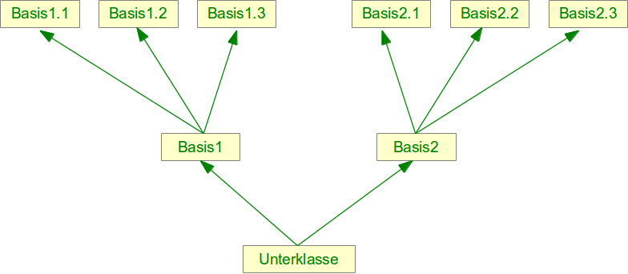

Beispiel für Mehrfachvererbung: Subklasse Wecker erbt von Basisklassen Uhr und Kalender

[figure not shown]

## Magische Methoden und Operatorüberladung

- Magische Methoden von Klassen können überschrieben werden
- Operatoren können für Klassen implementiert werden
- Operatoren erweitern die Funktionalität von Klassen

Für den Ausdruck $4 + 5 = 9$ ist $+$ der Operator, $4$ und $5$ sind die Operanden.

Bisher behandelte magische Methoden: `__init__, __del__, __str__`

Vollständige Liste aller magischen Methoden und Operatoren in Python: https://docs.python.org/3/reference/datamodel.html

Einige grundlegende magische Methoden

```python
object.__new__(cls[, ...])       # object creation
object.__init__(self[, ...])     # object initialization
object.__del__(self)             # object deletion
object.__str__(self)             # string representation of object
object.__bool__(self)            # boolean representation of object
```

Einige magische Methoden relevant für Containerklassen

```python
object.__len__(self)                   # length of container
object.__contains__(self, item)        # search (x in container)
object.__getitem__(self, index)        # get item at index (a = container[i])
object.__setitem__(self, index, item)  # set item at index (container[i] = 3)
```

Vergleichsoperatoren

```python
object.__lt__(self, other)   # <  (less than)
object.__le__(self, other)   # <= (less than or equal)
object.__eq__(self, other)   # == (equal)
object.__ne__(self, other)   # != (not equal)
object.__gt__(self, other)   # >  (greater than)
object.__ge__(self, other)   # >= (greater than or equal)
```

Beispiel: Operator < (*less than*) wird zum Sortieren verwendet

```python
class Person:
    def __init__(self, name):
        self.name = name

    def __lt__(self, other):  # operator < is called during sorting
        return self.name < other.name

scientists = [Person("Newton"), Person("Curie"), Person("Einstein")]

for scientist in sorted(scientists):
    print(scientist.name)
```

```
Curie
Einstein
Newton
```

Binäre Operatoren (2 Operanden, **erzeugen neues Objekt**)

```python
object.__add__(self, other)            # +
object.__sub__(self, other)            # -
object.__mul__(self, other)            # *
object.__matmul__(self, other)         # @
object.__truediv__(self, other)        # /
object.__floordiv__(self, other)       # //
object.__mod__(self, other)            # %
object.__pow__(self, other[, modulo])  # **
object.__lshift__(self, other)         # <<
object.__rshift__(self, other)         # >>
object.__and__(self, other)            # &
object.__or__(self, other)             # |
object.__xor__(self, other)            # ^
```

Erweiterte Zuweisungen (**modifizieren *"in-place"***)

```python
object.__iadd__(self, other)             # +=
object.__isub__(self, other)             # -=
object.__imul__(self, other)             # *=
object.__idiv__(self, other)             # /=
object.__ifloordiv__(self, other)        # //=
object.__imod__(self, other)             # %=
object.__ipow__(self, other[, modulo])   # **=
object.__ilshift__(self, other)          # <<=
object.__irshift__(self, other)          # >>=
object.__iand__(self, other)             # &=
object.__ior__(self, other)              # |=
object.__ixor__(self, other)             # ^=
```

Beispiel für Additionsoperator (Standard und Zuweisung)

```python
class Vector2d:
    def __init__(self, x, y):
        self.x = x
        self.y = y

    def __add__(self, other):   # return new object with result
        return Vector2d(self.x + other.x, self.y + other.y)

    def __iadd__(self, other):  # modify in-place and return reference to self
        self.x += other.x
        self.y += other.y
        return self

a = Vector2d(3, 7)
b = Vector2d(10, 20)
c = Vector2d(400, 800)
d = a + b        # __add__ method is called
print(d.x, d.y)
a += c           # __iadd__ method is called
print(a.x, a.y)
```

```
13 27
403 807
```

Unäre Operatoren (1 Operand)

```python
object.__neg__(self)               # -
object.__pos__(self)               # +
object.__abs__(self)               # abs()
object.__invert__(self)            # ~
object.__int__(self)               # int()
object.__float__(self)             # float()
object.__round__(self[, ndigits])  # round()
object.__floor__(self)             # floor()
object.__ceil__(self)              # ceil()
```

Magische Methoden für das `with`-Statement

```python
object.__enter__(self)                                # entering 'with' block
object.__exit__(self, exc_type, exc_value, traceback) # exiting 'with' block
```

Beispiel: Dateizugriff

```python
with open("testFile.txt") as file:
    pass
# file is closed after with block
```

Die Datei muss nicht manuell geschlossen werden, da dies automatisch in der Methode `__exit__` passiert.

## Zusammenfassung

- Klassenattribute sind für alle Instanzen einer Klasse gleich
- Statische Methoden sind weder an Klasse noch Instanz gebunden
- Klassenmethoden sind an Klasse gebunden
- Properties ermöglichen einen einfachen, gekapselten Zugriff auf Attribute
- Vererbung definiert Beziehung zwischen Basis- und Subklassen
- Geerbte Attribute und Methoden können überschrieben werden
- Klassen können von mehreren Basisklassen erben
- Magische Methoden und Operatoren können Funktionalität einer Klasse erweitern